# Delhi Air Quality Analysis

### by Jackson Fleege

```python
# Importing packages that will be used throughout the course of this file
import pandas as pd
import matplotlib.pyplot as plt
import seaborn as sns
import sqlite3
```

## Background

### About the Dataset

This dataset contains daily records of air pollutant concentrations collected over time, including PM2.5, PM10, NO₂, SO₂, CO, and Ozone. It also logs the Air Quality Index (AQI), along with date (day, month, year) also includes number of holidays and weekday representation. It is ideal for developing models to predict AQI, study pollution patterns, and analyze the effects of temporal or holiday factors on air quality.

```python
# Importing dataset that will be used to draw and collect data so that we can make decisive conclusions
df = pd.read_csv("final_dataset.csv")
df.head()
```

|  | Date | Month | Year | Holidays_Count | Days | PM2.5 | PM10 | NO2 | SO2 | CO | Ozone | AQI |
| --- | --- | --- | --- | --- | --- | --- | --- | --- | --- | --- | --- | --- |
| 0 | 1 | 1 | 2021 | 0 | 5 | 408.80 | 442.42 | 160.61 | 12.95 | 2.77 | 43.19 | 462 |
| 1 | 2 | 1 | 2021 | 0 | 6 | 404.04 | 561.95 | 52.85 | 5.18 | 2.60 | 16.43 | 482 |
| 2 | 3 | 1 | 2021 | 1 | 7 | 225.07 | 239.04 | 170.95 | 10.93 | 1.40 | 44.29 | 263 |
| 3 | 4 | 1 | 2021 | 0 | 1 | 89.55 | 132.08 | 153.98 | 10.42 | 1.01 | 49.19 | 207 |
| 4 | 5 | 1 | 2021 | 0 | 2 | 54.06 | 55.54 | 122.66 | 9.70 | 0.64 | 48.88 | 149 |

### Research Question

Is more CO produced on average by the residents and businesses of the Delhi region on weekdays (numbered 1-5 on the table) or weekends (numbered 6-7)?

### Procedure

To accurately measure the difference in concentration of CO between weekdays and weekends, we're going to collect averages on days numbered 1-5 in the "Days" column and 6-7 in the "Days" column to properly account for days Monday-Friday and Saturday-Sunday, respectively. With this data, we're going to plot the distributions to make a decision on the null hypothesis. The null will be tested a significance level of a = .05.

### Null Hypothesis

There is no difference in the proportion of CO emissions over time between the weekdays and weekends by the residents and businesses of the Delhi region.

## Conducting the Comparison of Proportions

Before conducting a statistical analysis on the data, it's important to get a sense of what details the data has to offer so that it can properly be worked with. To start, it's important to assure the data is clean so that a figure can be reached on how many observations there are for each day.

```python
# Getting a sense of the dataset's structure and descriptive infromation
df.info
df.describe()
df['Days'].value_counts()
```

```
Days
5    209
6    209
7    209
1    209
2    209
3    208
4    208
Name: count, dtype: int64
```

Using the info and describe calls, the data can now be properly sorted so that the days can be put into two unique categories: Weekdays and Weekends.

After grabbing the two day types, the respective mean, standard deviation, and variance was calculated; starting with the Weekdays, then Weekends. Finally, both days were combined and printed so that they can be viewed easier and the comparisons can be better drawn.

```python
# Creating the "Weekday" and "Weekend" qualifications
# so that we can calculate the mean, deviation, and variance of both
df['DayType'] = df['Days'].apply(lambda x: 'Weekday' if x in [1, 2, 3, 4, 5] else 'Weekend')

# Mean, deviation, variation for CO for weekdays
weekday_CO_mean = df[df['DayType'] == 'Weekday']['CO'].mean()
weekday_CO_dev = df[df['DayType'] == 'Weekday']['CO'].std()
weekday_CO_var = df[df['DayType'] == 'Weekday']['CO'].var()

# Mean, deviation, variation for CO for weekends
weekend_CO_mean = df[df['DayType'] == 'Weekend']['CO'].mean()
weekend_CO_dev = df[df['DayType'] == 'Weekend']['CO'].std()
weekend_CO_var = df[df['DayType'] == 'Weekend']['CO'].var()

# Grouped means, deviation, variance
co_means = df.groupby('DayType')['CO'].mean()
co_dev = df.groupby('DayType')['CO'].std()
co_var = df.groupby('DayType')['CO'].var()

print("\nGrouped Means:")
print(co_means)

print("\nGrouped Standard Deviations:")
print(co_dev)

print("\nGrouped Variances:")
print(co_var)
```

```
Grouped Means:
DayType
Weekday    1.028408
Weekend    1.019402
Name: CO, dtype: float64

Grouped Standard Deviations:
DayType
Weekday    0.618021
Weekend    0.584032
Name: CO, dtype: float64

Grouped Variances:
DayType
Weekday    0.381949
Weekend    0.341093
Name: CO, dtype: float64
```

#### or for easier viewing:

```python
# Creating and displaying a summary of the data rounded for better viewing
summary_table = pd.DataFrame({
    'Mean CO': [1.028408, 1.019402],
    'Std Dev': [0.618021, 0.584032],
    'Variance': [0.381949, 0.341093]
}, index=['Weekday', 'Weekend'])

# Display the table
display(summary_table.round(3))
```

|  | Mean CO | Std Dev | Variance |
| --- | --- | --- | --- |
| Weekday | 1.028 | 0.618 | 0.382 |
| Weekend | 1.019 | 0.584 | 0.341 |

When looking at the initial statistics, it can be seen that numerically the differences are somewhat similar. Using this information, a bar chart can be created to establish a better sense of how the means, standard deviations, and variances stack up visually between the CO emissions on the Weekdays and Weekends.

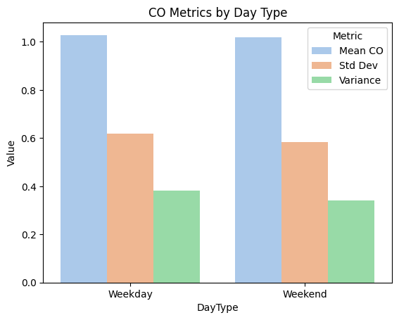

```python
# Create variable to be used in plotting
df_melted = summary_table_reset.melt(id_vars='DayType', var_name='Metric', value_name='Value')

# Orientating the data properly by axies
sns.barplot(x='DayType', y='Value', hue='Metric', data=df_melted, palette='pastel')
plt.title("CO Metrics by Day Type")
plt.ylabel("Value")
plt.show()
```

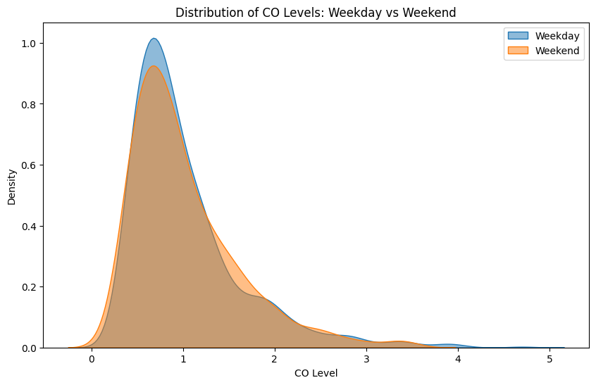

```python
# Setup/formatting
plt.figure(figsize=(10, 6))
sns.kdeplot(data=df[df['DayType'] == 'Weekday'], x='CO', fill=True, label='Weekday', alpha=0.5)
sns.kdeplot(data=df[df['DayType'] == 'Weekend'], x='CO', fill=True, label='Weekend', alpha=0.5)

# Labels for graph
plt.title('Distribution of CO Levels: Weekday vs Weekend')
plt.xlabel('CO Level')
plt.ylabel('Density')
plt.legend()
plt.show()
```

```python
# Import scripy.stats for t-test
from scipy.stats import ttest_ind

# Declaring new types to work with
week_CO = df[df["DayType"] == "Weekday"]["CO"]
weekend_CO = df[df["DayType"] == "Weekend"]["CO"]

# Running and printing the t-test between Weekday and Weekend carbon emissions
t_stat, p_val = ttest_ind(week_CO, weekend_CO, equal_var=False)  # t-test
print("t-statistic:", t_stat)
print("p-value:", p_val)
```

```
t-statistic: 0.26194434581649556
p-value: 0.7934309489393148
```

#### or for easier viewing:

```python
# Creating and displaying a summary of the t-test and p-value
second_summary_table = pd.DataFrame({
    't-statistic': [0.26194434581649556],
    'p-value': [0.7934309489393148]
}, index=['Result:'])

# Display the table
display(second_summary_table.round(3))
```

|  | t-statistic | p-value |
| --- | --- | --- |
| Result: | 0.262 | 0.793 |

## Conclusion

The p-value of p = 0.793 > 0.05 (79.3%) provides very weak evidence against the null model, suggesting that the observed difference in CO emissions in the Delhi region between Weekdays and Weekends could occur by chance and is not statistically significant. Therefore, we do not have strong enough evidence to conclude that the proportion of CO emissions over time between the weekdays and weekends by the residents and businesses of the Delhi region, thus failing to reject the null hypothesis.

Furthermore, we cannot generalize these results to a larger population as there is no guarantee our sample was representative of the larger population, in this case more regions and or countries.

## Final Summary

Based on the analysis of Delhi’s air quality data:

- The average CO levels are very similar across weekdays (1.028 ppm) and weekends (1.019 ppm).
- Variability is also similar, with standard deviations around 0.6.
- A two-sample t-test confirms that this difference is **not statistically significant** (p = 0.793).

**Conclusion:** There is no evidence to support that weekdays contribute more CO pollution than weekends.